# Bad weather Kelheim Demo

Oleksandr Soboliev

## **Research Meteostat**

After some researches about meteostat data nearest station in DE that belongs to Kelheim region are:

- “Mallersdorf-Pfaffenberg/Niederbayern” with an id: “D3147”
- “Neumarkt / Höhenberg” with and id: “69110”
- Uebungsdorf / Emhof

there are many of them so I am starting to think about extracting all from the Bayern or extract the nearest from longtitude/latitude point with the Kelheim shapefile(using json and Euclid distances)

[Kelheim has no weather station, but it could be reconstructed with 2 other](https://weatherspark.com/y/70370/Average-Weather-in-Kelheim-Germany-Year-Round)

Hohenfels with id: “10775” and Ingolstadt with id:“10860” **kelheim_data = {weight1}x{hohenfels} + {weight2}x{inglstadt}**

Also this site shows, that there are many of the Kelheim stations in this area, but meteostat doesn’t contain them https://www.wunderground.com/dashboard/pws/IKELHE5

## **Research Weatherstack**

```r
weatherstack_kelheim = read_delim("data/Kelheim_weather_since_july_2008.csv",delim = ",")
print(weatherstack_kelheim)
```

```
## # A tibble: 120,312 × 6
##    date        hour description precip visibility totalsnow_daily
##    <date>     <dbl> <chr>        <dbl>      <dbl>           <dbl>
##  1 2008-07-01     0 Clear            0         10               0
##  2 2008-07-01   100 Clear            0         10               0
##  3 2008-07-01   200 Clear            0         10               0
##  4 2008-07-01   300 Clear            0         10               0
##  5 2008-07-01   400 Clear            0         10               0
##  6 2008-07-01   500 Clear            0         10               0
##  7 2008-07-01   600 Sunny            0         10               0
##  8 2008-07-01   700 Sunny            0         10               0
##  9 2008-07-01   800 Sunny            0         10               0
## 10 2008-07-01   900 Sunny            0         10               0
## # … with 120,302 more rows
```

What to take as a reffer point isn’t clear because of the date(before/after covid) and weather type (sunny,clear,temperature) Also there is no temperature in it :/

## **Import mobility from Google**

```r
#global_mobility = read_delim("https://www.gstatic.com/covid19/mobility/Global_Mobility_Report.csv",",")
#de_mobility = global_mobility %>% filter(country_region_code == "DE")
```

```r
#print(unique(de_mobility$sub_region_1))
```

As we can see the most precise region to filter data from is Bavaria :/

Relevant data for the , mobility

```r
#bavaria_mobility = de_mobility %>% filter(sub_region_1 == "Bavaria")
#bavaria_mobility = bavaria_mobility %>% #dplyr::select(country_region,sub_region_1,date,residential_percent_change_from_baseline) %>%
#  mutate(residential_percent_change_from_baseline = -residential_percent_change_from_baseline,
#         source = "Google")%>%
#  rename(BundeslandID = sub_region_1,not_at_home_change = residential_percent_change_from_baseline)
#bavaria_mobility = bavaria_mobility %>% dplyr::select(date,BundeslandID,not_at_home_change,source)
#Need to filter out weekends

#plt = ggplot(bavaria_mobility)+
#  geom_point(aes(x = date,y = not_at_home_change))
#ggplotly(plt)
```

## **Import mobility from Senozon**

```r
snz_mobility = read_delim("data/LK_mobilityData_weekdays.csv",";")
```

```r
#Kelheim
snz_mobility_kelheim = snz_mobility %>% filter(Landkreis == "Landkreis Kelheim") %>% mutate(source = "senozon") %>% dplyr::select(-outOfHomeDuration) %>% rename(not_at_home_change = percentageChangeComparedToBeforeCorona)
snz_mobility_kelheim$date = as.Date(strptime(snz_mobility_kelheim$date,"%Y%m%d"))

#Berlin
snz_mobility_berlin = snz_mobility %>% filter(Landkreis == "Berlin") %>% mutate(source = "senozon") %>% dplyr::select(-outOfHomeDuration) %>% rename(not_at_home_change = percentageChangeComparedToBeforeCorona)
snz_mobility_berlin$date = as.Date(strptime(snz_mobility_berlin$date,"%Y%m%d"))

colors <- c("Berlin" = "blue", "Kelheim" = "red")

plt = ggplot()+
  geom_point(data = snz_mobility_kelheim,aes(x = date,y = not_at_home_change,color = "Berlin"))+
  geom_point(data = snz_mobility_berlin,aes(x = date,y = not_at_home_change,color = "Kelheim"))+
  scale_colour_manual(values = colors)
ggplotly(plt)
```

[interactive chart not shown]

## **Aggregate 2 sources**

We take berlin weather from station in Schoenefeld with id = 10384

```r
# think about duration of description column
# Kelheim
weatherstack_kelheim_daily = weatherstack_kelheim %>%
  group_by(date) %>%
  summarize(description = description,precip_day = sum(precip),visibility_mean = mean(visibility),totalsnow_daily = mean(totalsnow_daily))
weatherstack_kelheim_weekly = weatherstack_kelheim_daily %>%
  mutate(year_week = paste0(isoyear(date),"-",isoweek(date))) %>%
  group_by(year_week) %>%
  summarize(description = description,date = first(date), precip_week = sum(precip_day),visibility_mean = mean(visibility_mean),totalsnow_weekly =sum( totalsnow_daily))
weatherstack_kelheim_weekly = unique(weatherstack_kelheim_weekly)
print(weatherstack_kelheim_weekly)
```

```
## # A tibble: 8,194 × 6
## # Groups:   year_week [717]
##    year_week description          date       precip_week visibility_mean totalsnow_weekly
##    <chr>     <chr>                <date>           <dbl>           <dbl>            <dbl>
##  1 2008-27   Clear                2008-07-01        185.            9.22                0
##  2 2008-27   Sunny                2008-07-01        185.            9.22                0
##  3 2008-27   Partly cloudy        2008-07-01        185.            9.22                0
##  4 2008-27   Patchy light rain    2008-07-01        185.            9.22                0
##  5 2008-27   Moderate rain        2008-07-01        185.            9.22                0
##  6 2008-27   Light drizzle        2008-07-01        185.            9.22                0
##  7 2008-27   Patchy light drizzle 2008-07-01        185.            9.22                0
##  8 2008-27   Mist                 2008-07-01        185.            9.22                0
##  9 2008-27   Fog                  2008-07-01        185.            9.22                0
## 10 2008-28   Fog                  2008-07-07       1289.            8.20                0
## # … with 8,184 more rows
```

```r
#Berlin

berlin_weather_weekly = berlin_weather_daily %>% filter(year(date) >=2020) %>%
  mutate(year_week = paste0(isoyear(date),"-",isoweek(date))) %>%
  group_by(year_week) %>%
  summarize(date = first(date), prcp_week = sum(prcp), tavg= mean(tavg),snow_week =sum( snow),wspd = mean(wspd),tmax = max(tmax)) %>%
  arrange(year_week)
print(berlin_weather_weekly)
```

```
## # A tibble: 148 × 7
##    year_week date       prcp_week  tavg snow_week  wspd  tmax
##    <chr>     <date>         <dbl> <dbl>     <dbl> <dbl> <dbl>
##  1 2020-1    2020-01-01      10.5  2.24         0  17.5   7.2
##  2 2020-10   2020-03-02       7.6  4.7          0  15.3  10.3
##  3 2020-11   2020-03-09      16    6.6          0  22.5  13.8
##  4 2020-12   2020-03-16       0    7.17         0  14.0  17.3
##  5 2020-13   2020-03-23       0.1  4.54         0  15.8  15.9
##  6 2020-14   2020-03-30       0.1  5.01         0  15.8  16.2
##  7 2020-15   2020-04-06       3.7 12            0  11.0  23.7
##  8 2020-16   2020-04-13       0.1  9.3          0  17.0  18.1
##  9 2020-17   2020-04-20       0   12.0          0  15.1  22.5
## 10 2020-18   2020-04-27      27.3 12.8          0  13.2  24
## # … with 138 more rows
```

```r
#mob_joined = rbind(snz_mobility_kelheim,bavaria_mobility)
#Kelheim
snz_mobility_kelheim_year_week = snz_mobility_kelheim %>%
  mutate(year_week = paste0(isoyear(date),"-",isoweek(date))) %>%
  group_by(year_week) %>%
  summarize(date = first(date),not_at_home_change = mean(not_at_home_change))
mob_joined_with_weather_kelheim = snz_mobility_kelheim_year_week %>% inner_join(weatherstack_kelheim_weekly, by = "year_week") %>% dplyr::select(-date.y) %>% rename(date = date.x)
print(mob_joined_with_weather_kelheim)
```

```
## # A tibble: 1,083 × 7
##    year_week date       not_at_home_change description             precip_week visibility_mean totalsnow_weekly
##    <chr>     <date>                  <dbl> <chr>                         <dbl>           <dbl>            <dbl>
##  1 2020-10   2020-03-06                  0 Partly cloudy                  653.            8.63             33.6
##  2 2020-10   2020-03-06                  0 Light rain                     653.            8.63             33.6
##  3 2020-10   2020-03-06                  0 Light sleet showers            653.            8.63             33.6
##  4 2020-10   2020-03-06                  0 Patchy rain possible           653.            8.63             33.6
##  5 2020-10   2020-03-06                  0 Overcast                       653.            8.63             33.6
##  6 2020-10   2020-03-06                  0 Moderate or heavy sleet        653.            8.63             33.6
##  7 2020-10   2020-03-06                  0 Patchy heavy snow              653.            8.63             33.6
##  8 2020-10   2020-03-06                  0 Light sleet                    653.            8.63             33.6
##  9 2020-10   2020-03-06                  0 Moderate rain                  653.            8.63             33.6
## 10 2020-10   2020-03-06                  0 Mist                           653.            8.63             33.6
## # … with 1,073 more rows
```

```r
#Berlin
snz_mobility_berlin_year_week = snz_mobility_berlin %>%
  mutate(year_week = paste0(isoyear(date),"-",isoweek(date))) %>%
  group_by(year_week) %>%
  summarize(date = first(date),not_at_home_change = mean(not_at_home_change))
mob_joined_with_weather_berlin = snz_mobility_berlin_year_week %>% inner_join(berlin_weather_weekly, by = "year_week") %>% dplyr::select(-date.y) %>% rename(date = date.x)
print(mob_joined_with_weather_berlin)
```

```
## # A tibble: 132 × 8
##    year_week date       not_at_home_change prcp_week  tavg snow_week  wspd  tmax
##    <chr>     <date>                  <dbl>     <dbl> <dbl>     <dbl> <dbl> <dbl>
##  1 2020-10   2020-03-06                  0       7.6  4.7          0  15.3  10.3
##  2 2020-11   2020-03-13                 -4      16    6.6          0  22.5  13.8
##  3 2020-12   2020-03-20                -26       0    7.17         0  14.0  17.3
##  4 2020-13   2020-03-27                -39       0.1  4.54         0  15.8  15.9
##  5 2020-14   2020-04-03                -37       0.1  5.01         0  15.8  16.2
##  6 2020-15   2020-04-10                  0       3.7 12            0  11.0  23.7
##  7 2020-16   2020-04-17                -32       0.1  9.3          0  17.0  18.1
##  8 2020-17   2020-04-24                -27       0   12.0          0  15.1  22.5
##  9 2020-18   2020-05-01                  9      27.3 12.8          0  13.2  24
## 10 2020-19   2020-05-08                 22       1.8 12.3          0  12.3  23.7
## # … with 122 more rows
```

```r
#First plot with colour as precipitation
shapes <- c("Berlin" = 5, "Kelheim" = 3)
plt_color = ggplot()+
  geom_point(data = mob_joined_with_weather_kelheim,aes(x = date,y = not_at_home_change,colour = precip_week,shape = "Kelheim"))+
  #geom_point(data = mob_joined_with_weather_berlin,aes(x = date,y = not_at_home_change,colour = prcp_week,shape = "Berlin"))+
  scale_color_gradient2()+
  scale_shape_manual(values = shapes)


ggplotly(plt_color)
```

[interactive chart not shown]

```r
#Second plot as another line as precipitation
plt_line = ggplot(mob_joined_with_weather_kelheim)+
  geom_point(aes(x = date,y = not_at_home_change))+
  geom_line(aes(x = date,y = precip_week*0.5,color = "red"))


ggplotly(plt_line)
```

[interactive chart not shown]

```r
plt_hist_precip = ggplot(mob_joined_with_weather_kelheim,aes(x = precip_week,y = not_at_home_change))+
  stat_summary_bin(fun = "mean",
                   geom = "bar",
                   binwidth = 2,fill = "blue")

ggplotly(plt_hist_precip)
```

[interactive chart not shown]

```r
plt_hist_visibility = ggplot(mob_joined_with_weather_kelheim,aes(x = visibility_mean,y = not_at_home_change))+
  stat_summary_bin(fun = "mean",
                   geom = "bar",
                   binwidth = 0.5,fill = "blue")

ggplotly(plt_hist_visibility)
```

[interactive chart not shown]

```r
plt_hist_totalsnow = ggplot(mob_joined_with_weather_kelheim,aes(x = totalsnow_weekly,y = not_at_home_change))+
  stat_summary_bin(fun = "mean",
                   geom = "bar",
                   binwidth = 7,fill = "blue")

ggplotly(plt_hist_totalsnow)
```

[interactive chart not shown]

```r
#this is a bad plot because it takes description of 1 day of the week
plt_hist_descr = ggplot(mob_joined_with_weather_kelheim,aes(x = description,y = not_at_home_change))+
  stat_summary_bin(fun = "mean",
                   geom = "bar",
                   binwidth = 5,fill = "blue")+
  coord_flip()

ggplotly(plt_hist_descr)
```

[interactive chart not shown]

## Let’s try it out with meteostat data, that contains scope of the 2022 without restictions

Ingolstadt data from id = 10860 station

```r
ingolstadt_weather = read_delim("https://bulk.meteostat.net/v2/daily/10860.csv.gz",",",col_names = FALSE)
colnames(ingolstadt_weather) = c("date", "tavg", "tmin", "tmax", "prcp", "snow", "wdir", "wspd", "wpgt", "pres", "tsun")


# We don't need data of weather before 2020, because of snz_mobility date, also data isn't precise

ingolstadt_weather = ingolstadt_weather %>% filter(year(date)>=2020)%>% replace_na(list(snow = 0))

print(ingolstadt_weather)
```

```
## # A tibble: 1,031 × 11
##    date        tavg  tmin  tmax  prcp  snow  wdir  wspd  wpgt  pres tsun
##    <date>     <dbl> <dbl> <dbl> <dbl> <dbl> <dbl> <dbl> <dbl> <dbl> <lgl>
##  1 2020-01-01  -0.8  -3.5   3.4   0       0    70   6.5  20.5 1036. NA
##  2 2020-01-02  -2.9  -6.1  -1.2   0       0   243   4    16.6 1033. NA
##  3 2020-01-03   1.2  -2.4   5.9   0.3     0   218   7.2  29.5 1028  NA
##  4 2020-01-04   4.4   3.4   6.2   0.5     0   278  20.5  48.2 1030  NA
##  5 2020-01-05   2.8  -1.8   4.5   0       0   271   9    38.9 1037. NA
##  6 2020-01-06  -1.2  -3.7   4.5   0       0   119   4.3  14.8 1032. NA
##  7 2020-01-07  -0.4  -5     2.6   0.9     0   233   5    24.1 1032. NA
##  8 2020-01-08   1    -2.3   3.2   0       0   100   2.9  13   1032. NA
##  9 2020-01-09   4.3  -0.1  10.8   0       0   109   2.9  11.2 1024. NA
## 10 2020-01-10   4.9  -1.2  11.2   0.2     0   230   9.4  37.1 1023  NA
## # … with 1,021 more rows
```

Hohenfels data from id = 10775 station

```r
hohenfels_weather = read_delim("https://bulk.meteostat.net/v2/daily/10775.csv.gz",",",col_names = FALSE)
colnames(hohenfels_weather) = c("date", "tavg", "tmin", "tmax", "prcp", "snow", "wdir", "wspd", "wpgt", "pres", "tsun")


# We don't need data of weather before 2020, because of snz_mobility date, also data isn't precise

hohenfels_weather = hohenfels_weather %>% filter(year(date)>=2020) %>% replace_na(list(snow = 0))

print(hohenfels_weather)
```

```
## # A tibble: 995 × 11
##    date        tavg  tmin  tmax  prcp  snow  wdir  wspd wpgt   pres tsun
##    <date>     <dbl> <dbl> <dbl> <dbl> <dbl> <dbl> <dbl> <lgl> <dbl> <lgl>
##  1 2020-01-01  -4.3  -8.2   1.5    NA     0    NA  NA   NA      NA  NA
##  2 2020-01-02  -4.5  -9.7  -0.7    NA     0   355   0.6 NA    1033  NA
##  3 2020-01-03   0.5  -2.5   4.5    NA     0   153   3.7 NA    1028. NA
##  4 2020-01-04   3.4   2.2   5.7    NA     0   264  15.5 NA    1028. NA
##  5 2020-01-05   1.3  -2.1   3.3    NA     0   334   3.7 NA    1036. NA
##  6 2020-01-06  -1.1  -3.6   2.5    NA     0    18   2.1 NA    1032. NA
##  7 2020-01-07   0.2  -3.4   3      NA     0   332   2.6 NA    1031. NA
##  8 2020-01-08   1.5   0.2   2.6    NA     0    84   3.4 NA      NA  NA
##  9 2020-01-09   4.1   1.5   9.3    NA     0    35   2.3 NA    1024. NA
## 10 2020-01-10   5.1   1.3   9.4    NA     0   323   3.8 NA    1022. NA
## # … with 985 more rows
```

As we can see in Hohenfels data isn’t that accurate and precipitation is data is missing fr year 2020, so for the further analysis we take only Ingolstadt data.

```r
ingolstadt_weather_weekly = ingolstadt_weather %>%
  mutate(year_week = paste0(isoyear(date),"-",isoweek(date))) %>%
  group_by(year_week) %>%
  summarize(date = first(date), prcp_week = sum(prcp), tavg= mean(tavg),snow_week =sum( snow),wspd = mean(wspd),tmax = max(tmax)) %>%
  arrange(year_week)
#ingolstadt_weather_weekly = unique(weatherstack_kelheim_weekly)
print(ingolstadt_weather_weekly)
```

```
## # A tibble: 148 × 7
##    year_week date       prcp_week  tavg snow_week  wspd  tmax
##    <chr>     <date>         <dbl> <dbl>     <dbl> <dbl> <dbl>
##  1 2020-1    2020-01-01       0.8  0.94         0  9.44   6.2
##  2 2020-10   2020-03-02      13.9  4.14         0 13.2    9.6
##  3 2020-11   2020-03-09      13.1  7.14         0 15.4   17.7
##  4 2020-12   2020-03-16       9.9  7.16         0  9.21  19
##  5 2020-13   2020-03-23       0    4.44         0 14.2   NA
##  6 2020-14   2020-03-30       0    4.61         0  7.86  17.3
##  7 2020-15   2020-04-06       0   12.2          0  5.23  22.4
##  8 2020-16   2020-04-13       3.8 10.9          0  8.23  23.6
##  9 2020-17   2020-04-20       0   12.9          0 14.7   21
## 10 2020-18   2020-04-27      18.6 11.3          0 10.3   20.1
## # … with 138 more rows
```

```r
mob_joined_with_ingolstadt = ingolstadt_weather_weekly %>%
  inner_join(snz_mobility_kelheim_year_week, by = "year_week") %>%
  dplyr::select(-date.x) %>%
  rename(date = date.y) %>%
  replace_na(list(tmax = 0))

print(mob_joined_with_ingolstadt)
```

```
## # A tibble: 132 × 8
##    year_week prcp_week  tavg snow_week  wspd  tmax date       not_at_home_change
##    <chr>         <dbl> <dbl>     <dbl> <dbl> <dbl> <date>                  <dbl>
##  1 2020-10        13.9  4.14         0 13.2    9.6 2020-03-06                  0
##  2 2020-11        13.1  7.14         0 15.4   17.7 2020-03-13                  0
##  3 2020-12         9.9  7.16         0  9.21  19   2020-03-20                -14
##  4 2020-13         0    4.44         0 14.2    0   2020-03-27                -23
##  5 2020-14         0    4.61         0  7.86  17.3 2020-04-03                -20
##  6 2020-15         0   12.2          0  5.23  22.4 2020-04-10                -18
##  7 2020-16         3.8 10.9          0  8.23  23.6 2020-04-17                -19
##  8 2020-17         0   12.9          0 14.7   21   2020-04-24                -17
##  9 2020-18        18.6 11.3          0 10.3   20.1 2020-05-01                -13
## 10 2020-19         2.3 13.3          0  6.73  25.8 2020-05-08                 -9
## # … with 122 more rows
```

```r
#First plot with colour as precipitation
fills <- c("Ingolstadt" = "blue", "Berlin" = "red")
plt_ing_color = ggplot(mob_joined_with_ingolstadt)+
  geom_point(aes(x = date,y = not_at_home_change,colour = prcp_week,fill = "Ingolstadt"))+
  geom_point(data = mob_joined_with_weather_berlin,aes(x = date,y = not_at_home_change,colour = prcp_week,fill = "Berlin"))+
  scale_color_gradient(low = "white",high = "black")+
  scale_fill_manual(values = fills)

ggplotly(plt_ing_color)
```

[interactive chart not shown]

```r
plt_ing_color = ggplot(mob_joined_with_ingolstadt)+
  geom_point(aes(x = date,y = not_at_home_change))+
  geom_line(aes(x = date,y = prcp_week,color = "Ingolstadt"))+
  #geom_line(data = berlin_weather_weekly,aes(x = date,y = prcp_week,color = "Berlin"))+
  scale_color_manual(values = fills)+
  ggtitle("Kelheim mobility with precipitation as line plot on same axis")

ggplotly(plt_ing_color)
```

[interactive chart not shown]

```r
# replace coluumn positioning

mob_joined_with_weather_berlin = mob_joined_with_weather_berlin %>% dplyr::select(year_week,prcp_week,tavg,snow_week,wspd,tmax,date,not_at_home_change)

mob_joined_with_weather_berlin = mob_joined_with_weather_berlin %>% mutate(landkreis = "Berlin")

mob_joined_with_ingolstadt = mob_joined_with_ingolstadt %>% mutate(landkreis = "Ingolstadt")

mob_joined_with_ing_berlin = rbind(mob_joined_with_ingolstadt,mob_joined_with_weather_berlin)
```

```r
plt_hist_precip_ing = ggplot(mob_joined_with_ing_berlin,aes(x = prcp_week,y = not_at_home_change,fill = landkreis))+
  stat_summary_bin(fun = "mean",
                   geom = "bar",
                   binwidth = 2,position =  position_dodge())

ggplotly(plt_hist_precip_ing)
```

[interactive chart not shown]

```r
plt_hist_precip_ing = ggplot(mob_joined_with_ing_berlin,aes(x = tavg,y = not_at_home_change,fill = landkreis))+
  stat_summary_bin(fun = "mean",
                   geom = "bar",
                   binwidth = 2,position = position_dodge2())

ggplotly(plt_hist_precip_ing)
```

[interactive chart not shown]

```r
plt_hist_precip_ing = ggplot(mob_joined_with_ing_berlin,aes(x = tmax,y = not_at_home_change,fill = landkreis))+
  stat_summary_bin(fun = "mean",
                   geom = "bar",
                   binwidth = 2)

ggplotly(plt_hist_precip_ing)
```

[interactive chart not shown]

```r
plt_hist_precip_ing = ggplot(mob_joined_with_ing_berlin,aes(x = snow_week,y = not_at_home_change,fill = landkreis))+
  stat_summary_bin(fun = "mean",
                   geom = "bar",
                   binwidth = 50)

ggplotly(plt_hist_precip_ing)
```

[interactive chart not shown]

```r
mob_joined_with_ing_berlin = mob_joined_with_ing_berlin %>%
  mutate(season = ifelse(month(date) %in% c(12,1,2),"winter",NA)) %>%
  mutate(season = ifelse(month(date) %in% c(3,4,5),"spring",season)) %>%
  mutate(season = ifelse(month(date) %in% c(6,7,8),"summer",season)) %>%
  mutate(season = ifelse(month(date) %in% c(9,10,11),"autumn",season))
```

```r
#insert also a data about overall in germany
plt_hist_season = ggplot(mob_joined_with_ing_berlin,aes(x = season,y = not_at_home_change,fill = landkreis))+
  stat_summary_bin(fun = "mean",
                   geom = "bar",
                   binwidth = 5,position = position_dodge())

ggplotly(plt_hist_season)
```

[interactive chart not shown]

So it seems that season has an enormous impact at mobility of citizens. Another important parameter can be description of the weather based on Kelheim statistics, we will merge it into Ingolstadt weather, because of the assumption, that Ingolstadt ad Kelheim have the similar weather properties.

```r
type_of_weather = unique(weatherstack_kelheim$description)

weatherstack_kelheim_year_week = weatherstack_kelheim %>% mutate(year_week = paste0(isoyear(date),"-",isoweek(date)))

week_description_impact = weatherstack_kelheim_year_week %>% group_by(year_week) %>% count(description)

week_description_impact = week_description_impact %>% pivot_wider(names_from = description,values_from = n)

#remove NAs
week_description_impact[is.na(week_description_impact)] = 0
print(week_description_impact)
```

```
## # A tibble: 717 × 46
## # Groups:   year_week [717]
##    year_week Clear   Fog Light dr…¹  Mist Moder…² Partl…³ Patch…⁴ Patch…⁵ Sunny Cloudy Heavy…⁶ Heavy…⁷ Light…⁸ Light…⁹ Moder…˟ Patch…˟ Patch…˟ Moder…˟ Overc…˟
##    <chr>     <int> <int>      <int> <int>   <int>   <int>   <int>   <int> <int>  <int>   <int>   <int>   <int>   <int>   <int>   <int>   <int>   <int>   <int>
##  1 2008-27      50     1          6     3       3      21       3       6    51      0       0       0       0       0       0       0       0       0       0
##  2 2008-28      22     5          6     6       3      34      12       9    14      3       3       3       3      12       9       3      21       0       0
##  3 2008-29      30     6          3    12       3      44       9       6    19      9       0       0       3       9       0       0      15       0       0
##  4 2008-30      27     0          3     9       0      54       9       0    33     18       0       0       3       0       0       0      12       0       0
##  5 2008-31      60     0          0     3       0      24       3       6    51      3       0       0       0       3       0       0       6       3       3
##  6 2008-32      54     3          3     0       3      27       0       0    48      3       0       0       0      12       0       0      12       3       0
##  7 2008-33      29     0          6     9       9      39      12       9    37      6       0       0       0       0       6       0       3       3       0
##  8 2008-34      29     0          0     6       6      54       0       3    43      0       0       3       0      12       0       0       3       3       6
##  9 2008-35      62     0          0    12       0      16       0       3    66      6       0       0       3       0       0       0       0       0       0
## 10 2008-36      26     6          6    19       0      17       0      12    34      0       0       0       9       6       0       0      21       6       0
## # … with 707 more rows, 26 more variables: `Thundery outbreaks possible` <int>, `Light sleet` <int>, `Moderate or heavy sleet` <int>,
## #   `Patchy heavy snow` <int>, `Freezing fog` <int>, Blizzard <int>, `Heavy snow` <int>, `Light snow` <int>, `Moderate or heavy rain with thunder` <int>,
## #   `Moderate or heavy snow showers` <int>, `Moderate or heavy snow with thunder` <int>, `Moderate snow` <int>, `Patchy light snow` <int>,
## #   `Patchy moderate snow` <int>, `Moderate or heavy freezing rain` <int>, `Light sleet showers` <int>, `Light snow showers` <int>,
## #   `Patchy sleet possible` <int>, `Patchy freezing drizzle possible` <int>, `Light freezing rain` <int>, `Heavy freezing drizzle` <int>,
## #   `Patchy snow possible` <int>, `Torrential rain shower` <int>, `Freezing drizzle` <int>, `Blowing snow` <int>, `Ice pellets` <int>, and abbreviated
## #   variable names ¹`Light drizzle`, ²`Moderate rain`, ³`Partly cloudy`, ⁴`Patchy light drizzle`, ⁵`Patchy light rain`, ⁶`Heavy rain`, …
```

```r
mob_joined_with_ingolstadt_description = mob_joined_with_ingolstadt %>% inner_join(week_description_impact, by = "year_week")
#normalize it to a percentage
#mob_joined_with_ingolstadt_description[type_of_weather] = mob_joined_with_ingolstadt_description[type_of_weather]/168 #168 hours a week

#Assumption not_at_home_change is calculated through individual weather impact normally
#=> each type of weather for the weak get its own weather impact based on not_at_home

#mob_joined_with_ingolstadt_description[type_of_weather] = mob_joined_with_ingolstadt_description[type_of_weather]*mob_joined_with_ingolstadt_description$not_at_home_change


print(mob_joined_with_ingolstadt_description)
```

```
## # A tibble: 107 × 54
##    year_…¹ prcp_…²  tavg snow_…³  wspd  tmax date       not_a…⁴ landk…⁵ Clear   Fog Light…⁶  Mist Moder…⁷ Partl…⁸ Patch…⁹ Patch…˟ Sunny Cloudy Heavy…˟ Heavy…˟
##    <chr>     <dbl> <dbl>   <dbl> <dbl> <dbl> <date>       <dbl> <chr>   <int> <int>   <int> <int>   <int>   <int>   <int>   <int> <int>  <int>   <int>   <int>
##  1 2020-10    13.9  4.14       0 13.2    9.6 2020-03-06       0 Ingols…     0     0       3     6       9      63       0       0     0      0       0       0
##  2 2020-11    13.1  7.14       0 15.4   17.7 2020-03-13       0 Ingols…     0     0      21     3       6      71       0       0     0      7       0       0
##  3 2020-12     9.9  7.16       0  9.21  19   2020-03-20     -14 Ingols…     4     6       0     6       3      96       0       0    12      2       0       0
##  4 2020-13     0    4.44       0 14.2    0   2020-03-27     -23 Ingols…    25     0       0     0       0      99       0       0    31      7       0       0
##  5 2020-14     0    4.61       0  7.86  17.3 2020-04-03     -20 Ingols…    22     0       0     0       0      99       0       0    21     11       0       0
##  6 2020-15     0   12.2        0  5.23  22.4 2020-04-10     -18 Ingols…     9     0       0     0       0     153       0       0     5      0       0       0
##  7 2020-16     3.8 10.9        0  8.23  23.6 2020-04-17     -19 Ingols…    11     0       0     0       0     106       0       0     1      3       0       0
##  8 2020-17     0   12.9        0 14.7   21   2020-04-24     -17 Ingols…    29     0       0     0       0      90       0       0    40      3       0       0
##  9 2020-18    18.6 11.3        0 10.3   20.1 2020-05-01     -13 Ingols…     0     0      12     9       3      90       3       3     0      3       0       0
## 10 2020-19     2.3 13.3        0  6.73  25.8 2020-05-08      -9 Ingols…     3     0       0     3       0     107       0       0     0     12       0       0
## # … with 97 more rows, 33 more variables: `Light rain` <int>, `Light rain shower` <int>, `Moderate or heavy rain shower` <int>,
## #   `Patchy light rain with thunder` <int>, `Patchy rain possible` <int>, `Moderate rain at times` <int>, Overcast <int>,
## #   `Thundery outbreaks possible` <int>, `Light sleet` <int>, `Moderate or heavy sleet` <int>, `Patchy heavy snow` <int>, `Freezing fog` <int>,
## #   Blizzard <int>, `Heavy snow` <int>, `Light snow` <int>, `Moderate or heavy rain with thunder` <int>, `Moderate or heavy snow showers` <int>,
## #   `Moderate or heavy snow with thunder` <int>, `Moderate snow` <int>, `Patchy light snow` <int>, `Patchy moderate snow` <int>,
## #   `Moderate or heavy freezing rain` <int>, `Light sleet showers` <int>, `Light snow showers` <int>, `Patchy sleet possible` <int>,
## #   `Patchy freezing drizzle possible` <int>, `Light freezing rain` <int>, `Heavy freezing drizzle` <int>, `Patchy snow possible` <int>, …
```

```r
mob_joined_with_ingolstadt_description_longer = mob_joined_with_ingolstadt_description%>% pivot_longer(cols = all_of(type_of_weather),names_to = "description",values_to = "value")# %>% filter(value!=0)

description_impact_overall = mob_joined_with_ingolstadt_description_longer %>%
  filter(value!=0) %>% #mutate(value = value*not_at_home_change)%>% mutate(value = ifelse(value>0,value*not_at_home_change,-value*not_at_home_change)) %>%
  group_by(description) %>% summarize(impact = mean(not_at_home_change))

plot_ly(data = description_impact_overall,x = ~description,y = ~impact,type= "bar")
```

[interactive chart not shown]

Another approach

```r
map_vector <- c("Clear","Sunny","Cloudy","Light","Light","Light","Light","Light","Light","Light","Light","Medium","Cloudy","Light","Light","Heavy","Heavy","Heavy","Light","Medium","Heavy","Heavy","Light","Heavy","Heavy","Heavy","Heavy","Heavy","Heavy","Light","Medium","Medium","Light","Heavy","Light","Light","Light","Light","Light","Heavy","Light","Medium","Heavy","Heavy","Heavy")
names(map_vector)<- type_of_weather
mob_joined_with_ingolstadt_description_longer_mapped = mob_joined_with_ingolstadt_description_longer
mob_joined_with_ingolstadt_description_longer_mapped$description = map_vector[(mob_joined_with_ingolstadt_description_longer_mapped$description)]

description_impact_max = mob_joined_with_ingolstadt_description_longer_mapped %>% group_by(year_week)%>%
  top_n(1,value) %>% group_by(description) %>% summarize(impact = mean(not_at_home_change))

description_impact = mob_joined_with_ingolstadt_description_longer_mapped %>% group_by(year_week)%>%
  top_n(1,value)

week_calender = as.Date(seq(ISOdate(2014,1,3),ISOdate(2022,12,1),by="week"))
week_calender = data.frame(date = week_calender)
week_calender = week_calender %>% mutate(year_week = paste0(year(date),"-",isoweek(date)))

mob_joined_with_ingolstadt_description_longer_mapped = mob_joined_with_ingolstadt_description_longer_mapped %>%
  inner_join(week_calender,by = "year_week")



plot_ly(data = description_impact_max,x = ~description,y = ~impact,type= "bar")
```

[interactive chart not shown]

```r
print(description_impact_max)
```

```
## # A tibble: 6 × 2
##   description impact
##   <chr>        <dbl>
## 1 Clear         2.75
## 2 Cloudy       -3.04
## 3 Heavy        -8.5
## 4 Light         2.32
## 5 Medium      -30
## 6 Sunny         9.86
```

## **Add stringency of covid policies to a data**

```r
json = fromJSON(file = "data/2022-10-08.json")
unlisted_json = unlist(json)
```

```r
deu_stringency = unlisted_json[grep("DEU.stringency_actual",names(unlisted_json))]
date_stringency = sapply(strsplit(names(deu_stringency),split = ".",fixed = TRUE),"[[",2)
df_stringency = data.frame(date = date_stringency,stringency = deu_stringency)
df_stringency = df_stringency %>% mutate(year_week = paste0(year(date),"-",isoweek(date)),stringency = as.numeric(stringency))%>%ungroup() %>% group_by(year_week) %>% summarize(stringency = mean(stringency))
```

## **Insert new data from kexi region**

```r
demandDRT = read_delim("data/allDemandByDate.csv")
```

## **Starting with a model**

After first data preparation and analysis, let’s try to make some predicitions about not_at_home duration based on plots that shown us a major impact on not_at_home variable, like *tavg*, *season*, *description*, *tavg*. Starting with a *linear model* and using *Ingolstadt data* limited by year 2020,2021

```r
description_impact = description_impact %>%
  mutate(season = ifelse(month(date) %in% c(12,1,2),"winter",NA)) %>%
  mutate(season = ifelse(month(date) %in% c(3,4,5),"spring",season)) %>%
  mutate(season = ifelse(month(date) %in% c(6,7,8),"summer",season)) %>%
  mutate(season = ifelse(month(date) %in% c(9,10,11),"autumn",season))
description_impact = description_impact %>% inner_join(df_stringency, by = "year_week")
```

## **Import holidays**

```r
help_function <- function(list1,list2){

}
```

```r
holidays2020 = read_csv2("data/Holidays2020.csv") %>% dplyr::select(1,2,3)
```

```
## ℹ Using "','" as decimal and "'.'" as grouping mark. Use `read_delim()` for more control.
```

```r
holidays2021 = read_csv2("data/Holidays2021.csv") %>% dplyr::select(1,2,3)
```

```
## ℹ Using "','" as decimal and "'.'" as grouping mark. Use `read_delim()` for more control.
```

```r
holidays2022 = read_csv2("data/Holidays2022.csv") %>% dplyr::select(1,2,3)
```

```
## ℹ Using "','" as decimal and "'.'" as grouping mark. Use `read_delim()` for more control.
```

```r
holidays = rbind(holidays2020,holidays2021,holidays2022)
holidays = holidays %>% mutate(EndDateTime1 = as.Date(mdy_hm(EndDateTime1)),
                               StartDateTime1 = as.Date(mdy_hm(StartDateTime1)))

holiday_days = c(seq(holidays$StartDateTime1[1],holidays$EndDateTime1[1],by = "days"))

for(i in 1:nrow(holidays)){
  holiday_days = append(holiday_days,seq(holidays$StartDateTime1[i],holidays$EndDateTime1[i],by = "days"))
}

df_holidays = data.frame(date = holiday_days,isHoliday = TRUE)

week_calender = data.frame(date = as.Date(seq(ISOdate(2020,1,1),ISOdate(2022,12,31),by = "days")))
week_calender = week_calender %>% mutate(year_week = paste0(year(date),"-",isoweek(date)))

train_data = description_impact %>% left_join(df_holidays, by ="date") %>% replace_na(list(isHoliday = FALSE))
```

```r
demandDRT_week = demandDRT %>% mutate(year_week = paste0(year(date),"-",week(date)))%>% ungroup() %>% group_by(year_week) %>% summarize(noRides = sum(noRides),noRequests = sum(noRequests),avgEuclidianDistance_m = mean(avgEuclidianDistance_m), avgTravelTime_s = mean(avgTravelTime_s))
demand_table = demandDRT_week %>% inner_join(description_impact,by = "year_week")

best_pred <- demand_table %>% ungroup() %>%
  dplyr::select(-noRides,-landkreis,-description ,-year_week,-date,-value,-season,-noRequests,-avgEuclidianDistance_m,-not_at_home_change,-avgTravelTime_s) %>%
  map_dbl(cor,y = demand_table$noRides) %>%
  map_dbl(abs) %>%
  sort(decreasing = TRUE)
print(best_pred)
```

```
##       tmax       tavg stringency  snow_week       wspd  prcp_week
##  0.3344624  0.2882144  0.1875461  0.1854279  0.1403376  0.0963633
```

```r
best_pred <- train_data %>% ungroup() %>%
  dplyr::select(-not_at_home_change,-landkreis,-description ,-year_week,-date,-value,-season) %>%
  map_dbl(cor,y = train_data$not_at_home_change) %>%
  map_dbl(abs) %>%
  sort(decreasing = TRUE)
print(best_pred)
```

```
## stringency  isHoliday       tavg       tmax  snow_week       wspd  prcp_week
## 0.69214595 0.31704769 0.20433516 0.12702375 0.08713315 0.05510309 0.04534375
```

```r
train_data = description_impact %>% left_join(df_holidays, by ="date") %>% replace_na(list(isHoliday = FALSE))



first_model = lm(not_at_home_change ~ ns(tavg,2)+stringency+description+isHoliday+date,
                 data = train_data)
stringency_coef = first_model$coefficients[3]

#train_data = train_data %>% mutate(not_at_home_change = not_at_home_change + stringency_coef*stringency)

second_model = lm(not_at_home_change ~ ns(tavg,1)+date+snow_week+prcp_week+description+isHoliday,
                 data = train_data)

mass_model = MASS::rlm(not_at_home_change ~ ns(tavg,2)+date+stringency+description,
                 data = train_data)
summary(first_model)
```

```
##
## Call:
## lm(formula = not_at_home_change ~ ns(tavg, 2) + stringency +
##     description + isHoliday + date, data = train_data)
##
## Residuals:
##      Min       1Q   Median       3Q      Max
## -14.4235  -2.7564   0.2551   3.0382   8.8056
##
## Coefficients:
##                     Estimate Std. Error t value Pr(>|t|)
## (Intercept)       -4.542e+02  5.140e+01  -8.838 3.23e-14 ***
## ns(tavg, 2)1       1.248e+01  5.240e+00   2.382  0.01909 *
## ns(tavg, 2)2       8.819e+00  1.913e+00   4.610 1.18e-05 ***
## stringency        -3.874e-01  4.426e-02  -8.753 4.95e-14 ***
## descriptionCloudy  4.561e+00  2.772e+00   1.645  0.10302
## descriptionHeavy   7.324e+00  4.417e+00   1.658  0.10040
## descriptionLight   5.070e+00  2.678e+00   1.893  0.06123 .
## descriptionMedium -1.030e+01  5.701e+00  -1.807  0.07373 .
## descriptionSunny   5.776e+00  3.049e+00   1.894  0.06105 .
## isHolidayTRUE     -4.470e+00  1.472e+00  -3.036  0.00305 **
## date               2.499e-02  2.674e-03   9.344 2.50e-15 ***
## ---
## Signif. codes:  0 '***' 0.001 '**' 0.01 '*' 0.05 '.' 0.1 ' ' 1
##
## Residual standard error: 4.857 on 101 degrees of freedom
## Multiple R-squared:  0.7915, Adjusted R-squared:  0.7708
## F-statistic: 38.33 on 10 and 101 DF,  p-value: < 2.2e-16
```

Need to check auto.arima approach

```r
colors = c("actual" = "blue","predicted" = "red","residuals" = "gray50")
model = first_model
test_data = train_data %>% add_predictions(model = model) %>% add_residuals(model = model)

ggplotly(ggplot(test_data) +
  geom_line(aes(x = date,y = not_at_home_change,color = "actual"))+
  geom_line(aes(x = date,y = pred,color = "predicted"))+
  geom_line(aes(x = date,y = resid,color = "residuals"))+
  scale_color_manual(values = colors))
```

[interactive chart not shown]

```r
barplot <- ggplot(test_data, aes(x = resid ))+
  geom_histogram(aes(y = stat(density)),colour="black", fill="white", binwidth=2)+
  geom_density( fill="#FF6666",adjust = 10,alpha = 0.5)


ggplotly(barplot)
```

[interactive chart not shown]

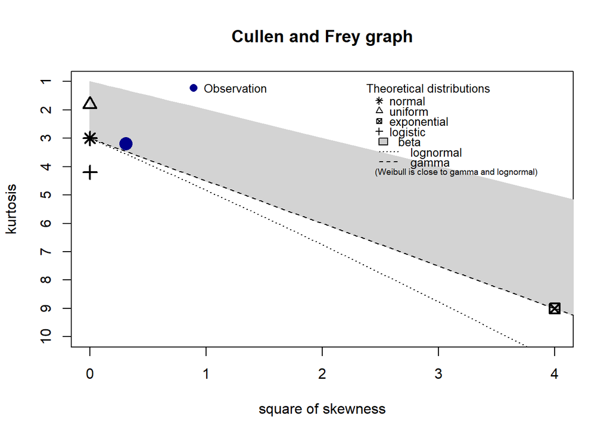

```
## summary statistics
## ------
## min:  -14.42351   max:  8.805632
## median:  0.255068
## mean:  -9.896849e-14
## estimated sd:  4.633465
## estimated skewness:  -0.5544615
## estimated kurtosis:  3.180313
```

```r
fitdistrplus::descdist(test_data$resid)
```

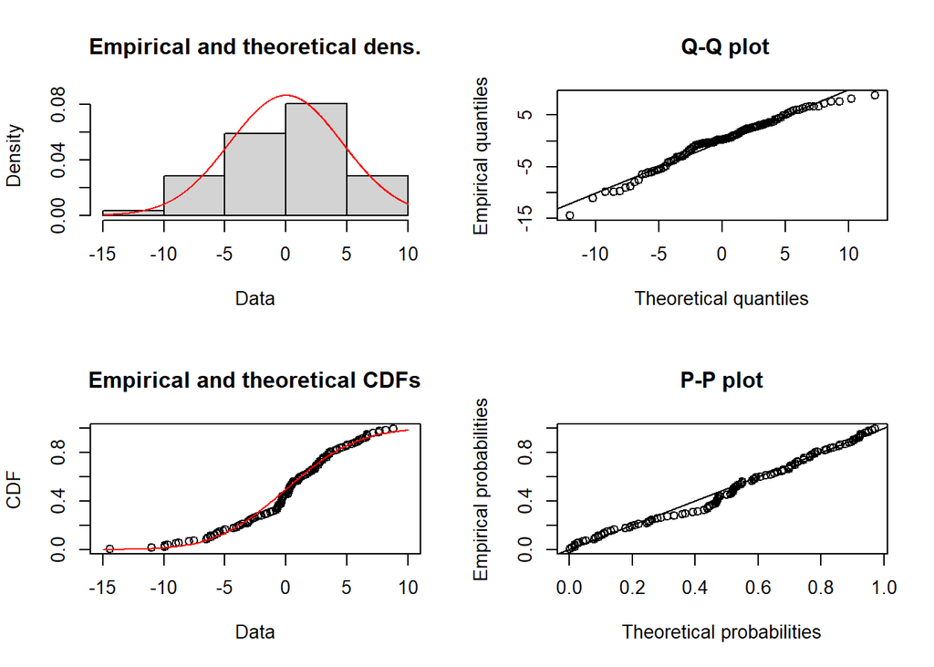

```r
normal_dist = fitdistrplus::fitdist(test_data$resid,"norm")
plot(normal_dist)
```

shapiro test p value

```r
print(shapiro.test(test_data$resid))
```

```
##
##  Shapiro-Wilk normality test
##
## data:  test_data$resid
## W = 0.97399, p-value = 0.02758
```